# Структура научной презентации

Простейший вариант

Осман АлиНиколай

1032239330@rudn.ru

Российский университет дружбы народов

2026-04-17

# Информация

## Докладчик

Осман АлиНиколай

студент

Российского университета дружбы народов им. П. Лумумбы

1032239330@rudn.ru

# Цель работы

Изучение механизмов изменения идентификатаровб применения SetUID и Sticky-битов. Получение практических навыков работы в консоли с дополнительными атрибутами. Рассмотрение работы механизма смены идентификатора процессов пользователей, а также влияние бита Sticky на запись и удаление файлов.

# Выполнение лабораторной работы

## Проверка рабочее пространство

До начала работы проверила, что имеется средства разработки:

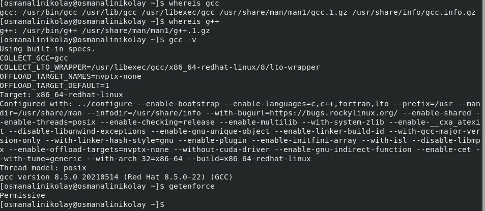

Проверка рабочее пространство

## Создание simpleid.c

Вошел в систему от имени пользователя guest и создала программу simpleid.c:

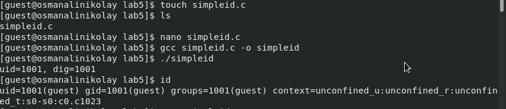

Создание simpleid.c

## код программы 1

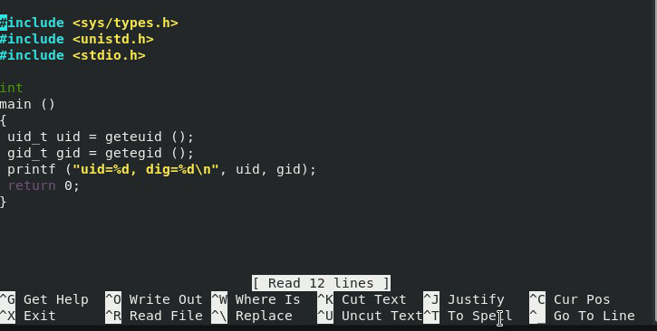

код программы 1

## simpleid.c

Скомпилировал программу и запускаю ее. Она выводит идентификатор пользователя и группы:

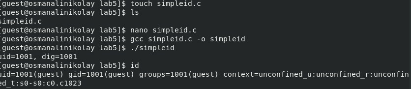

simpleid.c

## simpleid2.c

Создал файл simpleid2.c добавив вывод действительных идентификаторов.

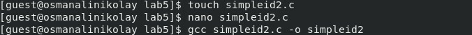

simpleid2.c

## Вывод simpleid2.c

Скомпилировал программу и запускаю ее.

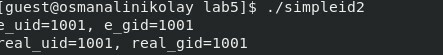

Вывод simpleid2.c

## Изменение права доступа на simpleid2.c

С помощью chown изменяю владельца файла на суперпользователя, с помощью chmod изменяю права доступа

## сравнение simpleid2 на id

Сравнение вывода программы и команды id, наша программа вывела только ограниченное количество информации

[figure not shown]

сравнение simpleid2 на id

## Программу readfile.c

Создал еще одну программу readfile.c

```
C++ листинг 3
int
main (int argc, char* argv[]){
  unsigned char buffer[16];
  size_t bytes_read;
  int i;
  int fd = open (argv[1], O_RDONLY);
  do{
  bytes_read = read (fd, buffer, sizeof (buffer));
  for (i =0; i < bytes_read; ++i) printf("%c", buffer[i]);}
  while (bytes_read == sizeof (buffer));
  close (fd);
  return 0;
}
```

## Программу readfile.c

[figure not shown]

Программу readfile.c

## Смена владельца файла и прав доступа

Снова от имени суперпользователи изменил владельца файла readfile. Далее изменил права доступа так, чтобы пользователь guest не смог прочесть содержимое файла

[figure not shown]

Смена владельца файла и прав доступа

## Попытка прочесть файл

Проверка прочесть файл от имени пользователя guest. Прочесть файл не удается. Попытка прочесть тот же файл с помощью программы readfile, в ответ получаем “отказано в доступе”

[figure not shown]

Попытка прочесть файл

## Попытка 3 прочесть файл

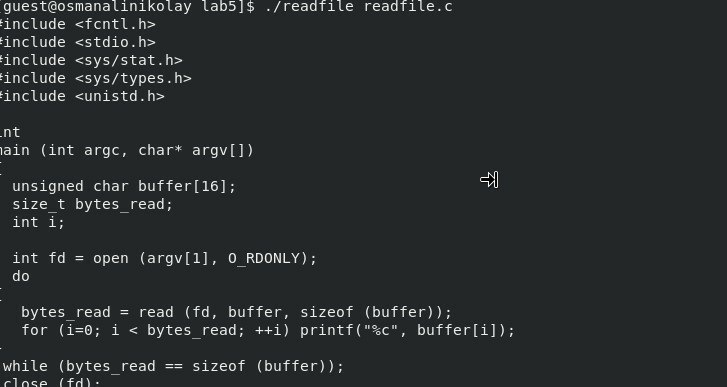

Попытка 3 прочесть файл

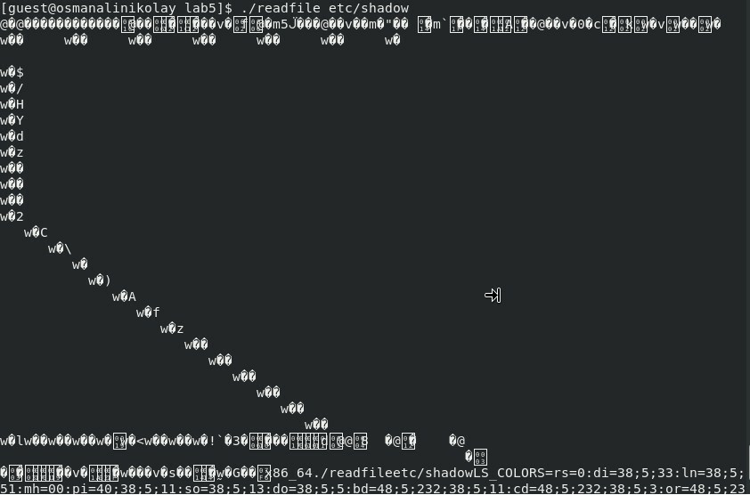

## Создание файла

От имени пользователя guest создаю файл с текстом.

[figure not shown]

Создание файла

## изменение права доступа

Добавляю права на чтение и запись для других пользователей

[figure not shown]

изменение права доступа

## Проверка файл на чтение, запись и удаление

[figure not shown]

Проверка файл на чтение, запись и удаление

## Снятие атрибута Sticky

От имени суперпользователя снял с директории атрибут Sticky.

[figure not shown]

Снятие атрибута Sticky

## Повтор предыдущих действий

[figure not shown]

Повтор предыдущих действий

## Изменение атрибутов

Возвращение директории tmp атрибута t от имени суперпользователя

[figure not shown]

Изменение атрибутов

# Выводы

Изучил механизм изменения идентификаторов, применил SetUID- и Sticky-биты. Получил практические навыки работы в консоли с дополнительными атрибутами. Рассмотрел работы механизма смены идентификатора процессов пользователей, а также влияние бита Sticky на запись и удаление файлов.